# Google AI Overviews for health questions: results in the main paper

Reproduces every number, table, and figure in the main text from the files in `../data` and the two coding workbooks in `../Manual Coding Checks`. Knit from the `analysis` folder; figures are saved to `figures/`. The analyses reported only in the supplement are in `AIO_Overviews_Supplement.R`.

**Robustness check.** To rerun every analysis on single-turn questions of 44 words or fewer (the Results paragraph on short single-turn questions and Table S12), uncomment the second line below and knit again. Figures are then saved with the suffix `_short`.

```r
SHORT_ONLY <- FALSE
# SHORT_ONLY <- TRUE    # robustness check: single-turn questions of 44 words or fewer
```

# Setup

```r
library(dplyr); library(tidyr); library(tibble); library(readr); library(stringr); library(purrr)
library(readxl); library(knitr); library(ggplot2)
```

```r
DATA   <- "../data"
MANUAL <- "../Manual Coding Checks"
FIG    <- "figures"
coding_sheet <- function(pattern) {
  f <- list.files(MANUAL, pattern, full.names = TRUE, ignore.case = TRUE)
  f <- f[!startsWith(basename(f), "~$")]
  if (length(f) != 1) stop("Put the one workbook matching '", pattern, "' in ", MANUAL)
  f }
HAL_HUMAN <- coding_sheet("HallOumi.*\\.xlsx$")     # statement support: human coders and HallOumi
JH_HUMAN  <- coding_sheet("JAMA.*HON.*\\.xlsx$")    # JAMA and HONcode: human coders
dir.create(FIG, showWarnings = FALSE)
```

```r
LV <- c("Low", "Medium", "High"); B_REPS <- 2000; SEED <- 0
CRIT <- c("JAMA_Authorship", "JAMA_Attribution", "JAMA_Disclosure", "JAMA_Currency", "HON_Authority", "HON_Complementarity")
rd     <- function(f) read_csv(file.path(DATA, f), guess_max = 1e6, show_col_types = FALSE, na = c("", "NA", "nan", "NaN", "None"))
r1     <- function(x, d = 1) round(x, d)
msd    <- function(x) c(n = sum(!is.na(x)), M = mean(x, na.rm = TRUE), SD = sd(x, na.rm = TRUE), Mdn = median(x, na.rm = TRUE),
                        min = min(x, na.rm = TRUE), max = max(x, na.rm = TRUE))
paired <- function(a, o) { d <- a - o; t <- t.test(a, o, paired = TRUE)
  c(n = length(d), M_aio = mean(a), SD_aio = sd(a), M_org = mean(o), SD_org = sd(o), t = unname(t$statistic),
    df = unname(t$parameter), p = t$p.value, dz = mean(d) / sd(d), dz_lo = t$conf.int[1] / sd(d), dz_hi = t$conf.int[2] / sd(d)) }
boot   <- function(x) { x <- x[!is.na(x)]; set.seed(SEED)
  b <- replicate(B_REPS, mean(sample(x, replace = TRUE)))
  c(n = length(x), est = mean(x), lo = unname(quantile(b, .025)), hi = unname(quantile(b, .975))) }
clip   <- function(x) pmin(pmax(x, 0), 1)
wilson <- function(k, n) { z <- 1.96; p <- k / n; m <- (p + z^2 / (2 * n)) / (1 + z^2 / n)
  h <- z * sqrt(p * (1 - p) / n + z^2 / (4 * n^2)) / (1 + z^2 / n); c(n = n, k = k, est = p, lo = m - h, hi = m + h) }
kappa  <- function(a, b) { po <- mean(a == b); pe <- mean(a) * mean(b) + (1 - mean(a)) * (1 - mean(b)); (po - pe) / (1 - pe) }
kci    <- function(a, b) {        # agreement, Cohen's kappa with asymptotic 95% CI, exact McNemar test (binary codes)
  t <- table(factor(a, 0:1), factor(b, 0:1)) / length(a); r <- rowSums(t); c <- colSums(t)
  po <- sum(diag(t)); pe <- sum(r * c); k <- (po - pe) / (1 - pe)
  A1 <- sum(diag(t) * (1 - (r + c) * (1 - k))^2); B1 <- (1 - k)^2 * (t[1, 2] * (c[1] + r[2])^2 + t[2, 1] * (c[2] + r[1])^2)
  se <- unname(sqrt((A1 + B1 - (k - pe * (1 - k))^2) / length(a)) / (1 - pe))
  c(n = length(a), agree = r1(100 * po), kappa = round(k, 2), lo = round(k - 1.96 * se, 2), hi = round(min(1, k + 1.96 * se), 2),
    human_supported = r1(100 * mean(a)), halloumi_supported = r1(100 * mean(b)),
    h1_m0 = sum(a == 1 & b == 0), h0_m1 = sum(a == 0 & b == 1),
    mcnemar_p = signif(binom.test(sum(a == 1 & b == 0), sum(a != b))$p.value, 3)) }
holm_pairs <- function(by) combn(LV, 2, simplify = FALSE) %>% map_dfr(function(pr) {   # by: lvl, n, k
  a <- by[by$lvl == pr[1], ]; b <- by[by$lvl == pr[2], ]
  tt <- suppressWarnings(prop.test(c(a$k, b$k), c(a$n, b$n), correct = FALSE))
  tibble(level_1 = pr[1], level_2 = pr[2], chisq = unname(tt$statistic), p = tt$p.value) }) %>%
  mutate(p_holm = p.adjust(p, "holm"))
```

Figure style (as in the paper: Arial, 95% CIs, white background).

```r
PAL  <- c(AIO = "#2a78d6", Organic = "#eb6834"); FONT <- "Arial"; ERR <- 1.96
minus <- function(s) gsub("-", "−", s, fixed = TRUE)
f_int <- function(x) formatC(x, format = "d", big.mark = ",")
f_num <- function(x, d) minus(formatC(x, format = "f", digits = d, big.mark = ","))
stars <- function(p) ifelse(p < .001, "***", ifelse(p < .01, "**", ifelse(p < .05, "*", "")))
n_lab <- function(l, n) paste0(l, "<br>(*n* = ", f_int(n), ")")
theme_ms <- function(base = 11) theme_classic(base_size = base, base_family = FONT) +
  theme(plot.background = element_rect(fill = "white", colour = NA), panel.background = element_rect(fill = "white", colour = NA),
        axis.line = element_line(colour = "black", linewidth = .4), axis.ticks = element_line(colour = "black", linewidth = .4),
        axis.text = element_text(colour = "black"), axis.title = element_text(colour = "black"),
        legend.position = "top", legend.title = element_blank(), plot.tag = element_text(face = "bold", size = rel(1.4)),
        plot.margin = margin(10, 16, 8, 8))
save_fig <- function(p, name, w, h) {         # 600-dpi PNG and vector PDF
  name <- paste0(name, if (SHORT_ONLY) "_short" else "")
  ggsave(file.path(FIG, paste0(name, ".png")), p, width = w, height = h, dpi = 600, bg = "white", device = ragg::agg_png)
  ggsave(file.path(FIG, paste0(name, ".pdf")), p, width = w, height = h, bg = "white", device = grDevices::cairo_pdf)
  p }
# Bars of a rate by level with 95% CIs and Holm-adjusted pairwise chi-square brackets (Figures 1 and 5).
# by: lvl, n, k (events), p, se; top: the highest CI end across both panels, so they share a y-axis.
plot_rate <- function(by, pw, xlab, ylab, tag, top) {
  step <- top * .13; xpos <- setNames(seq_along(LV), LV)
  br <- pw %>% mutate(x1 = xpos[level_1], x2 = xpos[level_2],
                      y = top + step * c(1.7, 2.7, 3.7)[match(paste(level_1, level_2), c("Low Medium", "Medium High", "Low High"))],
                      lab = ifelse(p_holm < .05, stars(p_holm), "ns"))
  tick <- step * .22
  ggplot(by, aes(lvl, p)) +
    geom_col(width = .6, fill = PAL[["AIO"]]) +
    geom_errorbar(aes(ymin = pmax(0, p - ERR * se), ymax = p + ERR * se), width = .16, linewidth = .45) +
    geom_text(aes(y = p + ERR * se + top * .035, label = paste0(f_num(100 * p, 1), "%")), vjust = 0, family = FONT, size = 3.6) +
    geom_segment(data = br, aes(x = x1, xend = x2, y = y, yend = y), inherit.aes = FALSE, linewidth = .4) +
    geom_segment(data = br, aes(x = x1, xend = x1, y = y, yend = y - tick), inherit.aes = FALSE, linewidth = .4) +
    geom_segment(data = br, aes(x = x2, xend = x2, y = y, yend = y - tick), inherit.aes = FALSE, linewidth = .4) +
    geom_text(data = br, aes(x = (x1 + x2) / 2, y = y + step * .06, label = lab), inherit.aes = FALSE, vjust = 0,
              family = FONT, size = 4) +
    scale_x_discrete(labels = function(l) n_lab(l, by$n[match(l, by$lvl)])) +
    scale_y_continuous(labels = function(x) paste0(round(100 * x), "%"), limits = c(0, top + step * 4.4),
                       expand = expansion(mult = c(0, 0))) +
    labs(x = xlab, y = ylab, tag = tag) +
    theme_ms() + theme(axis.text.x = ggtext::element_markdown(colour = "black", lineheight = 1.15))
}
```

# Data

The analysed questions (all but the 241 excluded) and, for the robustness check, the short single-turn subset. Then the two quality gates: overviews with at least 200 characters of text (gate 1) and pages with readable text (gate 2). The paired sample has readable pages in both arms.

```r
QS <- rd("questions.csv") %>% filter(excluded == 0)
if (SHORT_ONLY) QS <- QS %>% filter(n_user_turns == 1, !has_assistant_turns, q_words <= 44)
keep <- function(d) d[d$q_index %in% QS$q_index, ]
Q  <- keep(rd("overviews.csv")) %>% mutate(aio_present = as.logical(aio_present))
S  <- keep(rd("sources.csv")) %>% mutate(text_quality = coalesce(text_quality, ""))
ST <- keep(rd("statements.csv"))
good <- Q$q_index[Q$aio_present & !is.na(Q$aio_text_len) & Q$aio_text_len >= 200]                 # gate 1
R  <- S %>% filter(q_index %in% good, text_quality == "ok", !is.na(text_len), text_len > 0)     # gate 2
pq <- R %>% distinct(q_index, source_type) %>% count(q_index) %>% filter(n == 2) %>% pull(q_index)
lv <- QS %>% select(q_index, risk_level, rubric_complexity)
c(questions = nrow(QS), aio_returned = sum(Q$aio_present), gate1 = length(good), paired = length(pq))
```

```
   questions aio_returned        gate1       paired
        3611         3481         3474         3103
```

# Methods

## Questions (Table 1) and searches

Questions by risk level and rubric complexity, question length in words, and the searches captured.

```r
addmargins(table(Risk = factor(QS$risk_level, LV), Complexity = factor(QS$rubric_complexity, LV)))
```

```
        Complexity
Risk      Low Medium High  Sum
  Low      29    148 1102 1279
  Medium  207    226 1179 1612
  High    143     24  553  720
  Sum     379    398 2834 3611
```

```r
round(msd(QS$q_words), 1)
```

```
     n      M     SD    Mdn    min    max
3611.0   43.6   44.5   31.0    2.0  899.0
```

```r
SE <- keep(rd("searches.csv")); err <- coalesce(SE$error, "")
failed <- grepl("serpapi_error|question_exception|aio_prefetch_failed", err, ignore.case = TRUE)
c(submitted = nrow(SE), failed = sum(failed), captured = sum(!failed), aio_returned = sum(Q$aio_present),
  pct_returned = r1(100 * sum(Q$aio_present) / sum(!failed)))
```

```
   submitted       failed     captured aio_returned pct_returned
      3611.0          1.0       3610.0       3481.0         96.4
```

## JAMA and HONcode coding against human coders

One human code per page (the worksheet keeps one coder’s codes on the pages that all three coders coded) against the automated code, pooled over the six criteria. Table S7 (supplement) breaks this down by criterion.

```r
auto <- rd("jama_hon_validation.csv") %>% select(url, all_of(CRIT))
hum_all <- read_excel(JH_HUMAN, sheet = "Coding Worksheet _Human") %>% filter(!is.na(url)) %>% mutate(url = str_trim(url)) %>%
  filter(!grepl("google\\.com/searchviewer|facebook\\.com", url, ignore.case = TRUE)) %>% select(Coder, url, all_of(CRIT)) %>%
  mutate(across(all_of(CRIT), ~ suppressWarnings(as.numeric(.x)))) %>%
  pivot_longer(all_of(CRIT), names_to = "criterion", values_to = "human") %>% filter(!is.na(human))
stopifnot(!anyDuplicated(hum_all[c("url", "criterion")]))          # one human code per page and criterion
hum <- hum_all %>% inner_join(auto %>% pivot_longer(all_of(CRIT), names_to = "criterion", values_to = "auto"), by = c("url", "criterion"))
hum %>% summarise(judgments = n(), pages = n_distinct(url), agreement = r1(100 * mean(human == auto)), kappa = round(kappa(human, auto), 2))
```

```
# A tibble: 1 × 4
  judgments pages agreement kappa
      <int> <int>     <dbl> <dbl>
1       174    29      83.9  0.68
```

## HallOumi against human coders

The 100 validation statements: two coders (60 and 40 statements) and HallOumi, each judging whether the cited pages support the statement.

```r
SUP <- "Supported? (1 = supported, 0 = not supported)"
VKEY <- c("Item", "Question ID", "Statement # in overview", "AI Overview statement being judged")
hv <- read_excel(HAL_HUMAN, sheet = "Human Coding", col_types = "text") %>% select(all_of(VKEY), Coder, human = all_of(SUP)) %>%
  inner_join(read_excel(HAL_HUMAN, sheet = "HallOumi Coding", col_types = "text") %>% select(all_of(VKEY), halloumi = all_of(SUP)), by = VKEY) %>%
  mutate(across(c(human, halloumi), ~ as.integer(str_trim(.x))))
stopifnot(nrow(hv) == 100, all(hv$human %in% 0:1), all(hv$halloumi %in% 0:1))
kci(hv$human, hv$halloumi)
```

```
                 n              agree              kappa                 lo
          1.00e+02           8.10e+01           6.10e-01           4.60e-01
                hi    human_supported halloumi_supported              h1_m0
          7.60e-01           6.70e+01           5.40e+01           1.60e+01
             h0_m1          mcnemar_p
          3.00e+00           4.43e-03
```

## Physician rubrics and the GPT-4.1 grader

Each overview’s HealthBench rubric criteria and GPT-4.1’s verdict on each. Overviews are scored as in HealthBench: points earned divided by the maximum positive points (overall, per axis, for accuracy and completeness together, and for consensus criteria), plus three rates.

```r
items  <- keep(rd("rubric_items.csv"))
grades <- rd("grades_gpt41.csv") %>% select(prompt_id, item_idx, met = criteria_met)
g <- items %>% inner_join(grades, by = c("prompt_id", "item_idx")) %>%
  left_join(QS %>% select(q_index, theme, risk = risk_level, cx = rubric_complexity, multi = has_assistant_turns), by = "q_index")
sc <- function(p, m) if (sum(p[p > 0]) == 0) NA_real_ else sum(p[m]) / sum(p[p > 0])
A <-g %>% group_by(q_index, prompt_id, theme, risk, cx, multi) %>% summarise(
  overall = sc(points, met), clinical = sc(points[axis %in% c("accuracy", "completeness")], met[axis %in% c("accuracy", "completeness")]),
  accuracy = sc(points[axis == "accuracy"], met[axis == "accuracy"]),
  completeness = sc(points[axis == "completeness"], met[axis == "completeness"]),
  context_awareness = sc(points[axis == "context_awareness"], met[axis == "context_awareness"]),
  communication_quality = sc(points[axis == "communication_quality"], met[axis == "communication_quality"]),
  instruction_following = sc(points[axis == "instruction_following"], met[axis == "instruction_following"]),
  consensus = sc(points[level == "cluster"], met[level == "cluster"]),
  harm = if (any(points < 0 & axis == "accuracy")) any(met[points < 0 & axis == "accuracy"]) else NA,
  acc_check = if (any(accuracy_check)) met[accuracy_check][1] else NA,
  emergency = if (any(emergency_behavior)) met[emergency_behavior][1] else NA, .groups = "drop")
n_per <- count(g, prompt_id)
c(overviews = nrow(A), criteria = nrow(g), median_per_overview = median(n_per$n),
  to_avoid = sum(g$points < 0), pct_to_avoid = r1(100 * mean(g$points < 0)))
```

```
          overviews            criteria median_per_overview            to_avoid
             3474.0             41180.0                12.0             12218.0
       pct_to_avoid
               29.7
```

Grader validation on HealthBench’s meta-evaluation: macro-F1 of GPT-4.1 against every physician grade on the 3,000 sampled rows, and the physician benchmark on the same rows (each physician against the other physicians, weighted by their number of grades), using simple-evals’ pairwise definition.

```r
me  <- rd("meta_eval_gpt41.csv")
lab <- map(strsplit(me$physician_labels, ";"), ~ as.logical(as.integer(.x)))
ids <- strsplit(me$physician_ids, ";")
mf1 <- function(self, other) {        # pairs of (rater, other grader); macro-F1 over met / not met
  ag <- self == other
  f1 <- function(s) { p <- mean(ag[self == s]); r <- mean(ag[other == s]); if (is.na(p) || is.na(r)) NA else if (p + r == 0) 0 else 2 * p * r / (p + r) }
  (f1(TRUE) + f1(FALSE)) / 2 }
pairs_model <- map2_dfr(me$gpt41_met, lab, ~ tibble(self = .x, other = .y))
phys <- map_dfr(seq_len(nrow(me)), function(i) { l <- lab[[i]]; id <- ids[[i]]
  map_dfr(seq_along(l), function(j) tibble(pid = id[j], self = l[j], other = l[-j])) })
pm <- phys %>% group_by(pid) %>% summarise(mf1 = mf1(self, other)) %>% filter(!is.na(mf1)) %>%
  left_join(count(tibble(pid = unlist(ids)), pid, name = "n"), by = "pid")
c(rows = nrow(me), gpt41_mf1 = round(mf1(pairs_model$self, pairs_model$other), 3), physicians_mf1 = round(weighted.mean(pm$mf1, pm$n), 3))
```

```
          rows      gpt41_mf1 physicians_mf1
      3000.000          0.707          0.681
```

# Results

## Analytic sample (Table 2)

```r
QA <- Q %>% filter(aio_present) %>% mutate(uncited = n_aio_sources == 0 | is.na(n_aio_sources)) %>%
  left_join(QS %>% select(q_index, q_words), by = "q_index")
rbind(aio_words = msd(QA$aio_text_words), sources_aio = msd(QA$n_aio_sources),
      sources_aio_citing = msd(QA$n_aio_sources[!QA$uncited]), sources_organic = msd(QA$n_organic)) %>% round(2)
```

```
                      n      M     SD Mdn min  max
aio_words          3481 283.16 121.72 255   7 1983
sources_aio        3481   7.70   4.60   7   0   38
sources_aio_citing 3154   8.50   4.07   8   1   38
sources_organic    3481   4.84   0.81   5   0    5
```

```r
c(cited = sum(!QA$uncited), uncited = sum(QA$uncited), pct_uncited = r1(100 * mean(QA$uncited)),
  organic_5 = sum(QA$n_organic >= 5), organic_4_or_fewer = sum(QA$n_organic < 5))
```

```
             cited            uncited        pct_uncited          organic_5
            3154.0              327.0                9.4             3322.0
organic_4_or_fewer
             159.0
```

## Uncited overviews (Figure 1)

Question length of uncited and cited overviews (Welch t test, pooled-SD Cohen’s d), uncited rates by complexity and risk (Cochran–Armitage trend tests), and Holm-adjusted pairwise tests (the brackets in Figure 1).

```r
u <- QA$q_words[QA$uncited]; k <- QA$q_words[!QA$uncited]; wt <- t.test(u, k)
sp <- sqrt(((length(u) - 1) * var(u) + (length(k) - 1) * var(k)) / (length(u) + length(k) - 2))
c(M_uncited = mean(u), SD_uncited = sd(u), M_cited = mean(k), SD_cited = sd(k),
  t = unname(wt$statistic), df = unname(wt$parameter), p = wt$p.value, d = (mean(u) - mean(k)) / sp) %>% signif(4)
```

```
 M_uncited SD_uncited    M_cited   SD_cited          t         df          p
 7.349e+01  8.046e+01  4.048e+01  3.798e+01  7.336e+00  3.412e+02  1.619e-12
         d
 7.547e-01
```

```r
unc <- map(c(rubric_complexity = "rubric_complexity", risk_level = "risk_level"), function(v) {
  by <- QA %>% filter(.data[[v]] %in% LV) %>% group_by(lvl = factor(.data[[v]], LV)) %>%
    summarise(n = n(), k = sum(uncited), .groups = "drop") %>% mutate(p = k / n, se = sqrt(p * (1 - p) / n))
  list(by = by, pw = holm_pairs(by), trend = prop.trend.test(by$k, by$n)) })
for (v in names(unc)) {
  print(kable(unc[[v]]$by %>% mutate(pct = r1(100 * p)) %>% select(lvl, n, uncited = k, pct), caption = v))
  print(kable(unc[[v]]$pw %>% mutate(across(c(chisq, p, p_holm), ~ signif(.x, 3)))))
  cat(v, ": Cochran-Armitage chi2(1) =", r1(unc[[v]]$trend$statistic, 2), ", p =", signif(unc[[v]]$trend$p.value, 3), "\n")
}
```

```
Table: rubric_complexity

|lvl    |    n| uncited|  pct|
|:------|----:|-------:|----:|
|Low    |  377|      16|  4.2|
|Medium |  386|      23|  6.0|
|High   | 2718|     288| 10.6|


|level_1 |level_2 | chisq|        p|   p_holm|
|:-------|:-------|-----:|--------:|--------:|
|Low     |Medium  |  1.16| 0.282000| 0.282000|
|Low     |High    | 15.10| 0.000103| 0.000309|
|Medium  |High    |  8.06| 0.004520| 0.009040|
rubric_complexity : Cochran-Armitage chi2(1) = 20.96 , p = 4.68e-06


Table: risk_level

|lvl    |    n| uncited|  pct|
|:------|----:|-------:|----:|
|Low    | 1228|      79|  6.4|
|Medium | 1560|     126|  8.1|
|High   |  693|     122| 17.6|


|level_1 |level_2 | chisq|      p| p_holm|
|:-------|:-------|-----:|------:|------:|
|Low     |Medium  |  2.73| 0.0988| 0.0988|
|Low     |High    | 59.00| 0.0000| 0.0000|
|Medium  |High    | 44.50| 0.0000| 0.0000|
risk_level : Cochran-Armitage chi2(1) = 55.57 , p = 9.02e-14
```

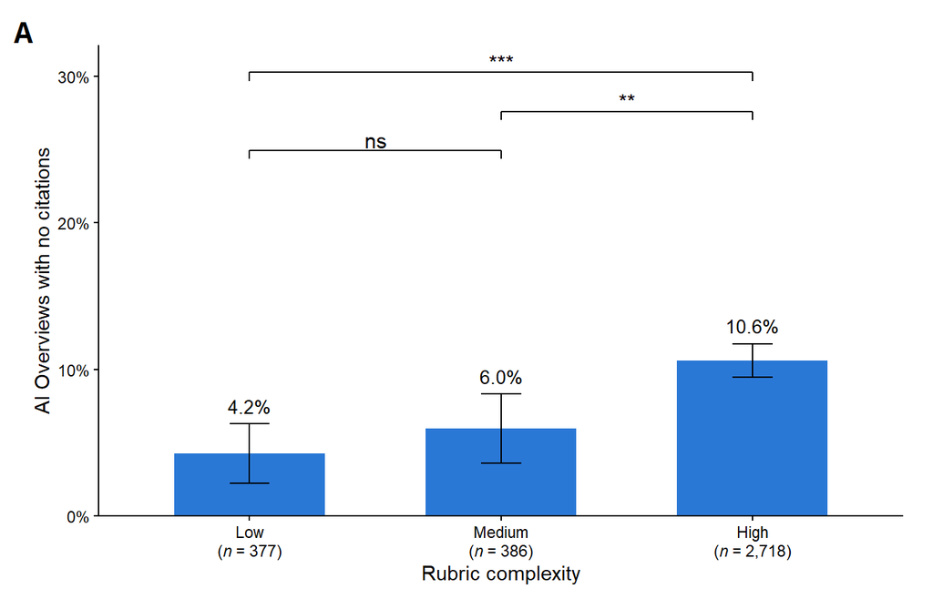

```r
top1 <- max(map_dbl(unc, ~ max(.x$by$p + ERR * .x$by$se)))
YL1 <- "AI Overviews with no citations"
save_fig(plot_rate(unc$rubric_complexity$by, unc$rubric_complexity$pw, "Rubric complexity", YL1, "A", top1), "Figure1A_uncited_by_rubric_complexity", 5.2, 4.6)
```

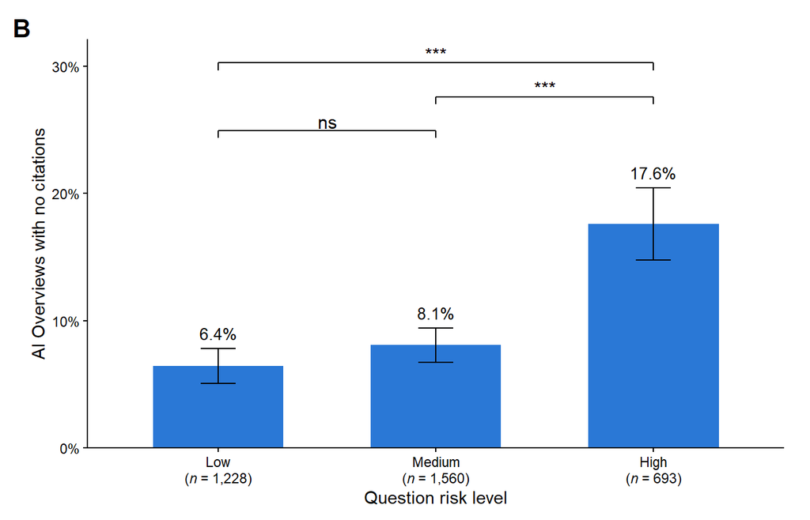

```r
save_fig(plot_rate(unc$risk_level$by, unc$risk_level$pw, "Question risk level", YL1, "B", top1), "Figure1B_uncited_by_risk_level", 5.2, 4.6)
```

## Overlap of sources (Figure 2)

Unique question–URL pairs among readable pages: cited by the overview only, by both, or in the organic top five only.

```r
ov <- R %>% distinct(q_index, source_type, url) %>% count(q_index, url, name = "arms") %>%
  left_join(R %>% distinct(q_index, url, source_type) %>% filter(source_type == "AIO") %>% transmute(q_index, url, aio = TRUE),
            by = c("q_index", "url"))
V <- c(pairs = nrow(ov), aio_only = sum(ov$arms == 1 & ov$aio %in% TRUE), both = sum(ov$arms == 2),
       organic_only = sum(ov$arms == 1 & is.na(ov$aio)))
c(V, aio_total = V[["aio_only"]] + V[["both"]], organic_total = V[["both"]] + V[["organic_only"]],
  pct_organic_shared = r1(100 * V[["both"]] / (V[["both"]] + V[["organic_only"]])),
  pct_organic_only = r1(100 * V[["organic_only"]] / (V[["both"]] + V[["organic_only"]])))
```

```
             pairs           aio_only               both       organic_only
           31688.0            17245.0             6412.0             8031.0
         aio_total      organic_total pct_organic_shared   pct_organic_only
           23657.0            14443.0               44.4               55.6
```

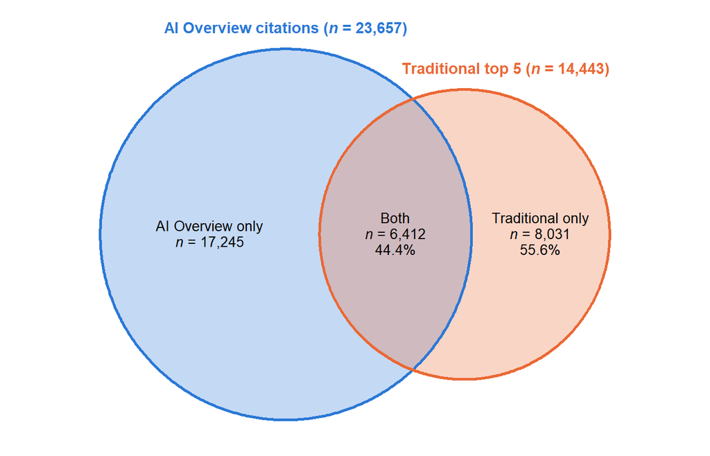

```r
# area-proportional Venn diagram; percentages are shares of the organic top five
nA <- V[["aio_only"]] + V[["both"]]; nB <- V[["both"]] + V[["organic_only"]]; rA <- sqrt(nA / pi); rB <- sqrt(nB / pi)
lens <- function(d, r1, r2) r1^2 * acos((d^2 + r1^2 - r2^2) / (2 * d * r1)) + r2^2 * acos((d^2 + r2^2 - r1^2) / (2 * d * r2)) -
  .5 * sqrt((-d + r1 + r2) * (d + r1 - r2) * (d - r1 + r2) * (d + r1 + r2))
dAB <- uniroot(function(d) lens(d, rA, rB) - V[["both"]], c(abs(rA - rB) + 1e-6, rA + rB - 1e-6), tol = 1e-10)$root
circ <- function(cx, r, set) { th <- seq(0, 2 * pi, length.out = 721); tibble(x = cx + r * cos(th), y = r * sin(th), set = set) }
cc <- bind_rows(circ(0, rA, "AIO"), circ(dAB, rB, "Organic"))
pct <- function(n) paste0(f_num(100 * n / nB, 1), "%")
lab_g <- tibble(x = c((-rA + dAB - rB) / 2, (dAB - rB + rA) / 2, (rA + dAB + rB) / 2), y = 0,
                txt = c(paste0("AI Overview only<br>*n* = ", f_int(V[["aio_only"]])),
                        paste0("Both<br>*n* = ", f_int(V[["both"]]), "<br>", pct(V[["both"]])),
                        paste0("Traditional only<br>*n* = ", f_int(V[["organic_only"]]), "<br>", pct(V[["organic_only"]]))))
head_g <- tibble(x = c(0, dAB + rB), y = c(rA, rB) + rA * .07, hj = c(.5, 1), set = c("AIO", "Organic"),
                 txt = c(paste0("**AI Overview citations (*n* = ", f_int(nA), ")**"), paste0("**Traditional top 5 (*n* = ", f_int(nB), ")**")))
save_fig(ggplot() +
  geom_polygon(data = cc, aes(x, y, fill = set, group = set), alpha = .28) +
  geom_path(data = cc, aes(x, y, colour = set, group = set), linewidth = .9) +
  ggtext::geom_richtext(data = lab_g, aes(x, y, label = txt), family = FONT, size = 3.6, lineheight = 1.1, fill = NA, label.colour = NA) +
  ggtext::geom_richtext(data = head_g, aes(x, y, label = txt, colour = set, hjust = hj), family = FONT, size = 3.8, vjust = 0,
                        fill = NA, label.colour = NA, label.padding = grid::unit(0, "pt")) +
  scale_fill_manual(values = PAL) + scale_colour_manual(values = PAL) + coord_equal(clip = "off") + theme_void(base_family = FONT) +
  theme(legend.position = "none", plot.background = element_rect(fill = "white", colour = NA), plot.margin = margin(12, 12, 12, 12)),
  "Figure2_aio_organic_url_overlap", 7, 4.6)
```

## Source quality (Figure 3)

Per-question mean JAMA and HONcode scores of the readable pages in each arm, compared with paired t tests (Benjamini–Hochberg across the six criteria); dz with its 95% CI. Table S10 (supplement) lists the means.

```r
qm <- R %>% filter(q_index %in% pq) %>% group_by(q_index, source_type) %>%
  summarise(across(c(all_of(CRIT), JAMA_Total, HON_Total), ~ mean(.x, na.rm = TRUE)), .groups = "drop")
arm <- function(v, d = qm) d %>% select(q_index, source_type, all_of(v)) %>% pivot_wider(names_from = source_type, values_from = all_of(v))
qt <- map_dfr(CRIT, ~ { x <- arm(.x); as_tibble_row(paired(x$AIO, x$Organic)) %>% mutate(measure = .x, .before = 1) }) %>%
  mutate(p_BH = p.adjust(p, "BH"))
qt %>% transmute(measure, n, t = round(t, 2), p_BH = signif(p_BH, 3), dz = round(dz, 2), dz_lo = round(dz_lo, 2), dz_hi = round(dz_hi, 2)) %>% kable()
```

| measure | n | t | p_BH | dz | dz_lo | dz_hi |
| --- | --- | --- | --- | --- | --- | --- |
| JAMA_Authorship | 3103 | -0.19 | 8.49e-01 | 0.00 | -0.04 | 0.03 |
| JAMA_Attribution | 3103 | -3.17 | 2.33e-03 | -0.06 | -0.09 | -0.02 |
| JAMA_Disclosure | 3103 | -6.68 | 0.00e+00 | -0.12 | -0.16 | -0.08 |
| JAMA_Currency | 3103 | -4.87 | 2.40e-06 | -0.09 | -0.12 | -0.05 |
| HON_Authority | 3103 | -10.45 | 0.00e+00 | -0.19 | -0.22 | -0.15 |
| HON_Complementarity | 3103 | -1.37 | 2.05e-01 | -0.02 | -0.06 | 0.01 |

```r
c(differ_after_BH = sum(qt$p_BH < .05), organic_higher = sum(qt$p_BH < .05 & qt$dz < 0))
```

```
differ_after_BH  organic_higher
              4               4
```

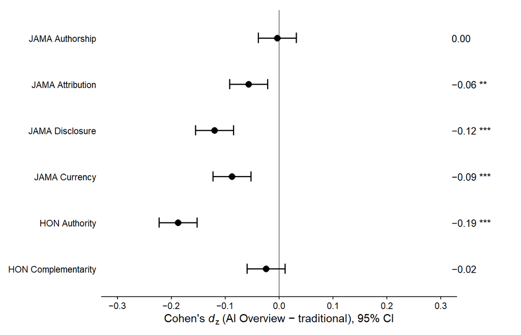

```r
LABEL <- setNames(sub("_", " ", CRIT), CRIT)
fb <- qt %>% mutate(lab = factor(LABEL[measure], levels = rev(LABEL)),
                    txt = minus(paste0(ifelse(round(dz, 2) == 0, "0.00", sprintf("%+.2f", dz)), " ", stars(p_BH))))
save_fig(ggplot(fb, aes(dz, lab)) +
  geom_vline(xintercept = 0, colour = "grey45", linewidth = .4) +
  geom_errorbar(aes(xmin = dz_lo, xmax = dz_hi), width = .22, linewidth = .6, colour = "black") +
  geom_point(size = 2.6, colour = "black") +
  geom_text(aes(x = .32, label = txt), hjust = 0, family = FONT, size = 3.4) +
  scale_x_continuous(breaks = seq(-.3, .3, .1), labels = function(x) minus(sprintf("%.1f", x))) +
  coord_cartesian(xlim = c(-.3, .3), clip = "off") +
  labs(x = expression(paste("Cohen's ", italic(d)[z], " (AI Overview − traditional), 95% CI")), y = NULL) +
  theme_ms() + theme(plot.margin = margin(10, 62, 8, 8), axis.line.y = element_blank(), axis.ticks.y = element_blank()),
  "Figure3_jama_honcode_effect_sizes", 7.5, 3.8)
```

The same comparison within each risk level and each rubric complexity level, on the JAMA and HONcode totals (unadjusted).

```r
ql <- map_dfr(c("risk_level", "rubric_complexity"), function(v) map_dfr(c("JAMA_Total", "HON_Total"), function(m)
  arm(m) %>% left_join(lv, by = "q_index") %>% group_by(level = .data[[v]]) %>%
    summarise(as_tibble_row(paired(AIO, Organic)), .groups = "drop") %>% mutate(variable = v, measure = m)))
ql %>% transmute(variable, measure, level, n, dz = round(dz, 2), p = signif(p, 3)) %>% kable()
```

| variable | measure | level | n | dz | p |
| --- | --- | --- | --- | --- | --- |
| risk_level | JAMA_Total | High | 559 | -0.13 | 1.72e-03 |
| risk_level | JAMA_Total | Low | 1122 | -0.13 | 1.44e-05 |
| risk_level | JAMA_Total | Medium | 1422 | -0.08 | 1.61e-03 |
| risk_level | HON_Total | High | 559 | -0.16 | 1.43e-04 |
| risk_level | HON_Total | Low | 1122 | -0.19 | 0.00e+00 |
| risk_level | HON_Total | Medium | 1422 | -0.10 | 1.16e-04 |
| rubric_complexity | JAMA_Total | High | 2386 | -0.11 | 2.00e-07 |
| rubric_complexity | JAMA_Total | Low | 359 | -0.14 | 9.77e-03 |
| rubric_complexity | JAMA_Total | Medium | 358 | -0.10 | 5.00e-02 |
| rubric_complexity | HON_Total | High | 2386 | -0.14 | 0.00e+00 |
| rubric_complexity | HON_Total | Low | 359 | -0.16 | 1.99e-03 |
| rubric_complexity | HON_Total | Medium | 358 | -0.12 | 2.24e-02 |

```r
c(comparisons = nrow(ql), favor_organic = sum(ql$dz < 0), significant = sum(ql$p < .05))
```

```
  comparisons favor_organic   significant
           12            12            12
```

## Statement grounding (Figures 4 and 5)

Composition of all overview statements and the support rate of statements scorable against a cited page.

```r
st <- ST %>% filter(q_index %in% good) %>%
  mutate(bucket = case_when(status == "uncited" & uncited_type == "uncited_factual" ~ "uncited factual",
                            status == "uncited" ~ "header or conversational", TRUE ~ status))
st %>% count(bucket) %>% mutate(pct = r1(100 * n / sum(n))) %>% kable()
```

| bucket | n | pct |
| --- | --- | --- |
| header or conversational | 4271 | 17.8 |
| skipped | 2618 | 10.9 |
| supported | 5735 | 23.8 |
| uncited factual | 4996 | 20.8 |
| unsupported | 6440 | 26.8 |

```r
sco <- st %>% filter(status %in% c("supported", "unsupported"))
c(statements = nrow(st), overviews = n_distinct(st$q_index), scorable = nrow(sco), pct_scorable = r1(100 * nrow(sco) / nrow(st)),
  supported = sum(sco$status == "supported"), not_supported = sum(sco$status == "unsupported"),
  support_rate = r1(100 * mean(sco$status == "supported"), 2))
```

```
   statements     overviews      scorable  pct_scorable     supported
      24060.0        3474.0       12175.0          50.6        5735.0
not_supported  support_rate
       6440.0          47.1
```

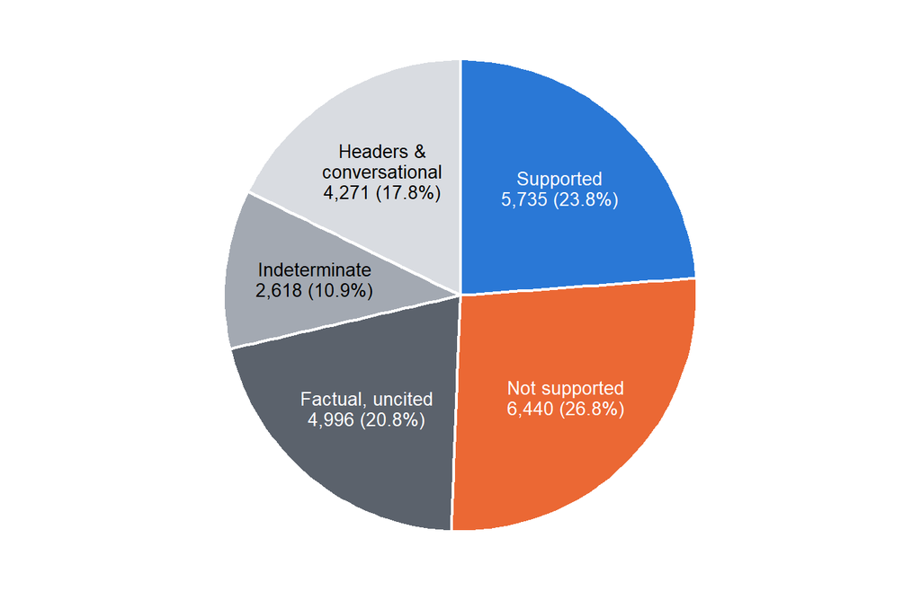

```r
fj <- st %>% count(bucket) %>% tibble::deframe()
fj <- tibble(part = c("Supported", "Not supported", "Factual, uncited", "Indeterminate", "Headers &\nconversational"),
             n = c(fj[["supported"]], fj[["unsupported"]], fj[["uncited factual"]], fj[["skipped"]], fj[["header or conversational"]])) %>%
  mutate(part = factor(part, levels = part), pct = 100 * n / sum(n), ymid = sum(n) - (cumsum(n) - n / 2),
         txt = paste0(part, "\n", f_int(n), " (", f_num(pct, 1), "%)"),
         ink = ifelse(part %in% c("Indeterminate", "Headers &\nconversational"), "black", "white"))
stopifnot(sum(fj$n) == nrow(st))
save_fig(ggplot(fj, aes(x = 1, y = n, fill = part)) +
  geom_col(width = 1, colour = "white", linewidth = .8) +
  geom_text(aes(x = 1.12, y = ymid, label = txt, colour = ink), family = FONT, size = 3.5, lineheight = .95) +
  coord_polar(theta = "y", start = 0, direction = -1) + scale_y_continuous(limits = c(0, sum(fj$n))) + xlim(c(.5, 1.5)) +
  scale_fill_manual(values = c("Supported" = PAL[["AIO"]], "Not supported" = PAL[["Organic"]], "Factual, uncited" = "#5b626c",
                               "Indeterminate" = "#a3a9b2", "Headers &\nconversational" = "#d9dce1")) +
  scale_colour_identity() + theme_void(base_family = FONT) +
  theme(legend.position = "none", plot.background = element_rect(fill = "white", colour = NA)),
  "Figure4_statement_composition", 6, 6)
```

The observed support rate with a 95% CI from resampling questions (statements are nested in questions), and the rate corrected for HallOumi’s misclassification: the Rogan–Gladen estimator with HallOumi’s sensitivity and specificity against the human coders on the 100 validation statements. Its 95% CI comes from a bootstrap (5,000 resamples) that resamples the validation statements by overview and the scorable statements by question.

```r
scq <- sco %>% group_by(q_index) %>% summarise(sup = sum(status == "supported"), n = n()) %>%
  left_join(QS %>% select(q_index, boot_order), by = "q_index") %>% arrange(boot_order)   # resampling order of the original analysis
boot_ratio <- function(num, den, B = 2000) {     # pooled rate sum(num) / sum(den), resampling questions
  set.seed(0); n <- length(num)
  b <- replicate(B, { i <- sample.int(n, n, replace = TRUE); sum(num[i]) / sum(den[i]) })
  c(est = sum(num) / sum(den), lo = unname(quantile(b, .025)), hi = unname(quantile(b, .975))) }
se_sp <- function(d) c(se = mean(d$halloumi[d$human == 1]), sp = mean(1 - d$halloumi[d$human == 0]))
rogan <- function(p, a) unname((p + a["sp"] - 1) / (a["se"] + a["sp"] - 1))
set.seed(0)
vcl <- split(seq_len(nrow(hv)), hv$`Question ID`); nv <- length(vcl); ns <- nrow(scq)
cb <- clip(replicate(5000, { vb <- hv[unlist(vcl[sample.int(nv, nv, replace = TRUE)]), ]; i <- sample.int(ns, ns, replace = TRUE)
  rogan(sum(scq$sup[i]) / sum(scq$n[i]), se_sp(vb)) }))
a <- se_sp(hv); obs <- boot_ratio(scq$sup, scq$n)
c(sensitivity = r1(100 * a[["se"]]), sens_k = sum(hv$halloumi[hv$human == 1]), sens_n = sum(hv$human == 1),
  specificity = r1(100 * a[["sp"]]), spec_k = sum(hv$halloumi[hv$human == 0] == 0), spec_n = sum(hv$human == 0),
  observed = r1(100 * obs[["est"]]), observed_lo = r1(100 * obs[["lo"]]), observed_hi = r1(100 * obs[["hi"]]),
  corrected = r1(100 * clip(rogan(obs[["est"]], a))), corrected_lo = r1(100 * unname(quantile(cb, .025, na.rm = TRUE))),
  corrected_hi = r1(100 * unname(quantile(cb, .975, na.rm = TRUE))))
```

```
 sensitivity       sens_k       sens_n  specificity       spec_k       spec_n
        76.1         51.0         67.0         90.9         30.0         33.0
    observed  observed_lo  observed_hi    corrected corrected_lo corrected_hi
        47.1         46.1         48.2         56.7         45.3         68.6
```

Support by rubric complexity and risk level (chi-square tests), with Holm-adjusted pairwise tests for Figure 5.

```r
sup <- map(c(rubric_complexity = "rubric_complexity", risk_level = "risk_level"), function(v) {
  by <- sco %>% left_join(lv, by = "q_index") %>% group_by(lvl = factor(.data[[v]], LV)) %>%
    summarise(n = n(), k = sum(status == "supported"), .groups = "drop") %>% mutate(p = k / n, se = sqrt(p * (1 - p) / n))
  list(by = by, pw = holm_pairs(by), chi = chisq.test(cbind(by$k, by$n - by$k))) })
for (v in names(sup)) {
  print(kable(sup[[v]]$by %>% mutate(rate = r1(100 * p)) %>% select(lvl, scored = n, supported = k, rate), caption = v))
  print(kable(sup[[v]]$pw %>% mutate(across(c(chisq, p, p_holm), ~ signif(.x, 3)))))
  cat(v, ": chi2(", sup[[v]]$chi$parameter, ", N = ", sum(sup[[v]]$by$n), ") = ", r1(sup[[v]]$chi$statistic, 2),
      ", p = ", signif(sup[[v]]$chi$p.value, 3), "\n", sep = "")
}
```

```
Table: rubric_complexity

|lvl    | scored| supported| rate|
|:------|------:|---------:|----:|
|Low    |   1366|       713| 52.2|
|Medium |   1433|       679| 47.4|
|High   |   9376|      4343| 46.3|


|level_1 |level_2 |  chisq|        p|   p_holm|
|:-------|:-------|------:|--------:|--------:|
|Low     |Medium  |  6.480| 1.09e-02| 0.021800|
|Low     |High    | 16.500| 4.81e-05| 0.000144|
|Medium  |High    |  0.564| 4.53e-01| 0.453000|
rubric_complexity: chi2(2, N = 12175) = 16.57, p = 0.000252


Table: risk_level

|lvl    | scored| supported| rate|
|:------|------:|---------:|----:|
|Low    |   4211|      1897| 45.0|
|Medium |   5776|      2823| 48.9|
|High   |   2188|      1015| 46.4|


|level_1 |level_2 | chisq|        p|   p_holm|
|:-------|:-------|-----:|--------:|--------:|
|Low     |Medium  | 14.30| 0.000156| 0.000467|
|Low     |High    |  1.04| 0.307000| 0.307000|
|Medium  |High    |  3.93| 0.047600| 0.095100|
risk_level: chi2(2, N = 12175) = 14.86, p = 0.000594
```

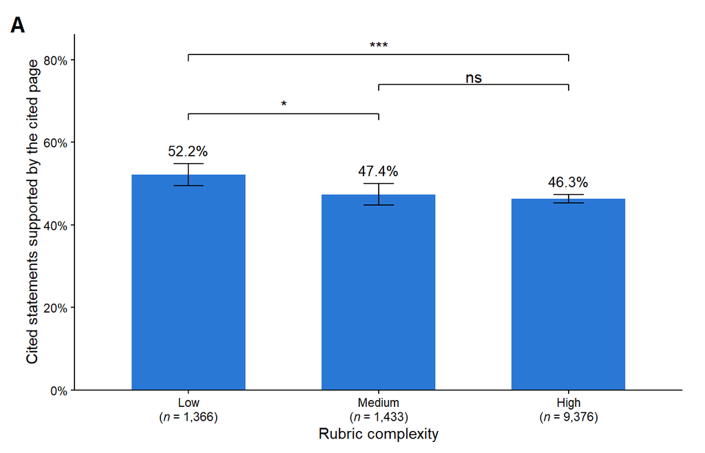

```r
top5 <- max(map_dbl(sup, ~ max(.x$by$p + ERR * .x$by$se)))
YL5 <- "Cited statements supported by the cited page"
save_fig(plot_rate(sup$rubric_complexity$by, sup$rubric_complexity$pw, "Rubric complexity", YL5, "A", top5), "Figure5A_support_by_rubric_complexity", 5.2, 4.6)
```

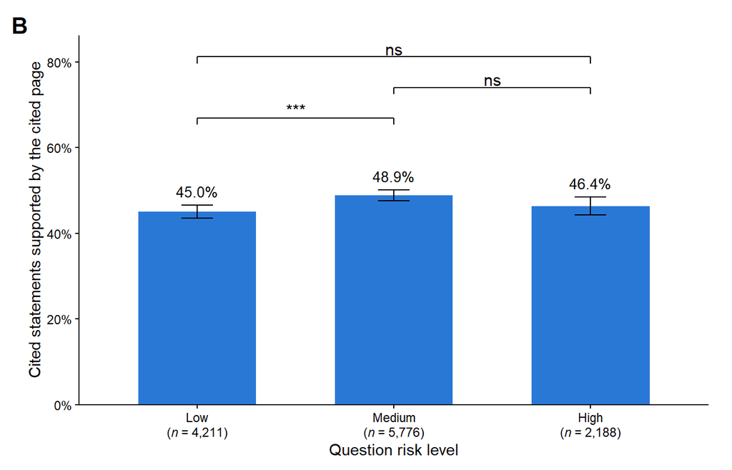

```r
save_fig(plot_rate(sup$risk_level$by, sup$risk_level$pw, "Question risk level", YL5, "B", top5), "Figure5B_support_by_risk_level", 5.2, 4.6)
```

## Accuracy against physician rubrics (Table 3)

Scores (% of available points, 95% bootstrap CIs) and rates (% of overviews, Wilson 95% CIs).

```r
SC <- c("overall", "clinical", "accuracy", "completeness", "context_awareness", "communication_quality", "consensus", "instruction_following")
map_dfr(SC, ~ as_tibble_row(boot(A[[.x]])) %>% mutate(measure = .x, .before = 1)) %>%
  mutate(across(c(est, lo, hi), ~ r1(100 * clip(.x))), n = as.integer(n)) %>% kable(caption = "Scores")
```

Scores

| measure | n | est | lo | hi |
| --- | --- | --- | --- | --- |
| overall | 3474 | 38.2 | 37.0 | 39.3 |
| clinical | 3460 | 39.3 | 38.0 | 40.7 |
| accuracy | 3016 | 54.2 | 52.6 | 55.8 |
| completeness | 2922 | 21.6 | 19.4 | 23.7 |
| context_awareness | 2401 | 32.3 | 29.8 | 34.6 |
| communication_quality | 1628 | 64.7 | 61.7 | 67.5 |
| consensus | 2764 | 84.2 | 83.2 | 85.2 |
| instruction_following | 477 | 32.4 | 26.3 | 37.9 |

```r
map_dfr(c("harm", "acc_check", "emergency"), ~ as_tibble_row(wilson(sum(A[[.x]], na.rm = TRUE), sum(!is.na(A[[.x]])))) %>%
  mutate(measure = .x, .before = 1)) %>% mutate(across(c(est, lo, hi), ~ r1(100 * .x))) %>% kable(caption = "Rates")
```

Rates

| measure | n | k | est | lo | hi |
| --- | --- | --- | --- | --- | --- |
| harm | 2065 | 459 | 22.2 | 20.5 | 24.1 |
| acc_check | 861 | 804 | 93.4 | 91.5 | 94.9 |
| emergency | 413 | 392 | 94.9 | 92.4 | 96.7 |

Where accuracy points were lost (positive criteria not met vs. negative criteria met, % of all lost accuracy points), and how often overviews that passed the general “no factually incorrect information” criterion still made an error physicians named for that question.

```r
acc  <- g %>% filter(axis == "accuracy")
lost <- c(missing_content = sum(acc$points[acc$points > 0 & !acc$met]), stated_errors = sum(-acc$points[acc$points < 0 & acc$met]))
r1(100 * lost / sum(lost), 0)
```

```
missing_content   stated_errors
             89              11
```

```r
pg <- A %>% filter(acc_check %in% TRUE, !is.na(harm))     # passed the general check; rubric also names specific errors
c(passed_general_check = nrow(pg), made_named_error = sum(pg$harm), pct = r1(100 * mean(pg$harm), 0))
```

```
passed_general_check     made_named_error                  pct
                 606                  168                   28
```

Clinical scores (accuracy and completeness) by rubric complexity and risk level, the share of each complexity level’s clinical criteria that are consensus criteria, and how often overviews met consensus and question-specific clinical criteria (positive criteria only).

```r
lvl <- function(v, x = "clinical", d = A) d %>% group_by(level = factor(.data[[v]], LV)) %>%
  summarise(as_tibble_row(boot(.data[[x]])), .groups = "drop") %>% mutate(across(c(est, lo, hi), ~ r1(100 * clip(.x))))
kable(lvl("cx"), caption = "Clinical score by complexity"); kable(lvl("risk"), caption = "Clinical score by risk")
```

Clinical score by complexity

| level | n | est | lo | hi |
| --- | --- | --- | --- | --- |
| Low | 371 | 76.7 | 71.9 | 81.4 |
| Medium | 381 | 28.8 | 23.0 | 34.4 |
| High | 2708 | 35.7 | 34.3 | 37.0 |

Clinical score by risk

| level | n | est | lo | hi |
| --- | --- | --- | --- | --- |
| Low | 1217 | 26.7 | 24.6 | 28.8 |
| Medium | 1554 | 43.4 | 41.3 | 45.4 |
| High | 689 | 52.4 | 49.3 | 55.4 |

```r
g %>% filter(axis %in% c("accuracy", "completeness")) %>% group_by(cx = factor(cx, LV)) %>%
  summarise(consensus_share = r1(100 * mean(level == "cluster"), 0))
```

```
# A tibble: 3 × 2
  cx     consensus_share
  <fct>            <dbl>
1 Low                 57
2 Medium               4
3 High                 9
```

```r
g %>% filter(axis %in% c("accuracy", "completeness"), points > 0) %>%
  group_by(criteria = ifelse(level == "cluster", "consensus", "question-specific")) %>%
  summarise(n = n(), pct_met = r1(100 * mean(met), 0))
```

```
# A tibble: 2 × 3
  criteria              n pct_met
  <chr>             <int>   <dbl>
1 consensus          3070      91
2 question-specific 18393      43
```

Clinical scores with referral criteria removed (HealthBench’s emergency-referral consensus criterion and every accuracy or completeness criterion about seeking or referring to care), by risk level.

```r
nr <- g %>% filter(axis %in% c("accuracy", "completeness"), !referral) %>% group_by(prompt_id) %>% summarise(noref = sc(points, met))
A2 <- A %>% left_join(nr, by = "prompt_id")
kable(lvl("risk", "noref", A2 %>% filter(!is.na(clinical))), caption = "Clinical score without referral criteria, by risk")
```

Clinical score without referral criteria, by risk

| level | n | est | lo | hi |
| --- | --- | --- | --- | --- |
| Low | 1208 | 22.5 | 19.8 | 25.0 |
| Medium | 1464 | 41.3 | 39.0 | 43.6 |
| High | 541 | 35.9 | 32.2 | 39.6 |

```r
c(excluded_no_criteria_left = sum(!is.na(A2$clinical) & is.na(A2$noref)))
```

```
excluded_no_criteria_left
                      247
```

## Accuracy, source quality, and grounding

Spearman correlations (rho to two decimals, as reported) of the clinical score with the JAMA and HONcode totals of the cited pages and with the support rate, and of the support rate with the accuracy and completeness scores separately (cited overviews with all three measures); the clinical score of uncited and cited overviews (Welch t test); and the correlation of the clinical score with overview length.

```r
hal  <- ST %>% group_by(q_index) %>% summarise(sup = sum(status == "supported"), uns = sum(status == "unsupported")) %>%
  mutate(support_rate = ifelse(sup + uns > 0, sup / (sup + uns), NA))
qual <- R %>% filter(source_type == "AIO") %>% group_by(q_index) %>%
  summarise(jama = mean(JAMA_Total, na.rm = TRUE), hon = mean(HON_Total, na.rm = TRUE))
D <- A2 %>% left_join(rd("graded_overviews.csv") %>% select(prompt_id, aio_words), by = "prompt_id") %>%
  left_join(Q %>% select(q_index, n_aio_sources), by = "q_index") %>% left_join(hal, by = "q_index") %>% left_join(qual, by = "q_index") %>%
  mutate(uncited = is.na(n_aio_sources) | n_aio_sources == 0, clinical_pts = 100 * clinical)
cd <- D %>% filter(!uncited, !is.na(support_rate), !is.na(jama), !is.na(hon), !is.na(clinical))
spear <- function(x, y) { ok <- !is.na(x) & !is.na(y); t <- cor.test(x[ok], y[ok], method = "spearman", exact = FALSE)
  c(rho = round(unname(t$estimate), 2), p = signif(t$p.value, 3), n = sum(ok)) }
rbind(JAMA = spear(cd$jama, cd$clinical), HONcode = spear(cd$hon, cd$clinical), grounding = spear(cd$support_rate, cd$clinical),
      grounding_accuracy = spear(cd$support_rate, cd$accuracy), grounding_completeness = spear(cd$support_rate, cd$completeness),
      overview_length = spear(D$aio_words, D$clinical))
```

```
                         rho        p    n
JAMA                   -0.05 2.88e-03 2973
HONcode                 0.10 1.07e-07 2973
grounding               0.01 4.67e-01 2973
grounding_accuracy      0.01 7.59e-01 2605
grounding_completeness -0.04 5.52e-02 2514
overview_length         0.14 1.32e-17 3460
```

```r
x <- D$clinical_pts[D$uncited & !is.na(D$clinical)]; y <- D$clinical_pts[!D$uncited & !is.na(D$clinical)]; tt <- t.test(x, y)
c(n_uncited = length(x), M_uncited = r1(mean(x)), n_cited = length(y), M_cited = r1(mean(y)),
  t = round(unname(tt$statistic), 2), df = r1(unname(tt$parameter)), p = signif(tt$p.value, 3))
```

```
n_uncited M_uncited   n_cited   M_cited         t        df         p
  320.000    40.400  3140.000    39.200     0.460   381.600     0.649
```